# PSTAT231HW6

### Exercise 5

Using `rpart.plot`, fit and visualize your best-performing pruned decision tree with the *training* set.

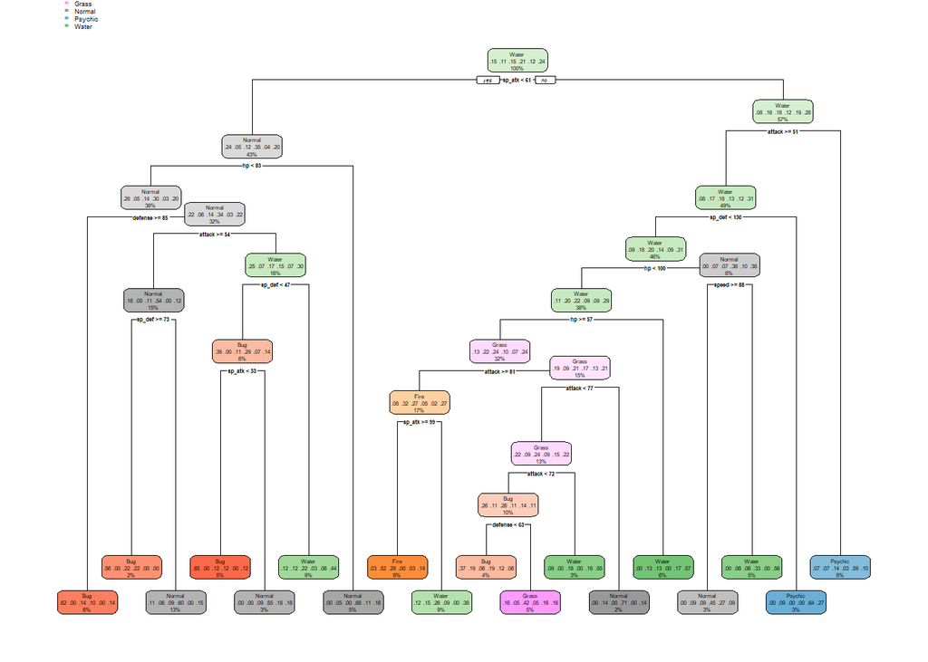

```r
best_complexity <- select_best(decision_tree_tune)
tree_final <- finalize_workflow(decision_tree_wkflow, best_complexity)
tree_final_fit <- fit(tree_final, data = Pokemon_train)
tree_final_fit %>%
  extract_fit_engine() %>%
  rpart.plot()
```

### Exercise 5

Now set up a random forest model and workflow. Use the `ranger` engine and set `importance = "impurity"`. Tune `mtry`, `trees`, and `min_n`. Using the documentation for `rand_forest()`, explain in your own words what each of these hyperparameters represent.

Create a regular grid with 8 levels each. You can choose plausible ranges for each hyperparameter. Note that `mtry` should not be smaller than 1 or larger than 8. **Explain why not. What type of model would `mtry = 8` represent?**

```r
bagging_spec <- rand_forest(mtry = .cols()) %>%
  set_engine("ranger", importance = "impurity") %>%
  set_mode("classification") %>%
  set_args(mtry = tune(),trees = tune(), min_n = tune())

rand_tree_wkflow <- workflow() %>%
  add_recipe(Pokemon_recipe) %>%
  add_model(bagging_spec)

Forest_grid <- grid_regular(mtry(range = c(1, 8)),trees(range = c(0, 8)), min_n(range = c(0, 4)),levels = 8)

#mtry is number of predictors randomly sampled at each split when creating the tree models. trees is the integer for the sample that is tested. min_n is the integer for the minimum number of data points in a node to split further.

#mtry = 1 means we randomly select one predictor for the test. Hence in this case mtry = 8 means select all predictors whenever we run the model
```